# Decline in HRT Usage and Breast Cancer Incidence in 17 countries

Arindam Basu

```r
## set the working directory

Mywd <- setwd("/Users/arindambose/GitHub/brca-study")

## Read the data into R

mydata <- read.csv("breastca.csv", header = TRUE, sep = ",")
mydata$hrtuse2 <- (mydata$declinehrtuse)^2
```

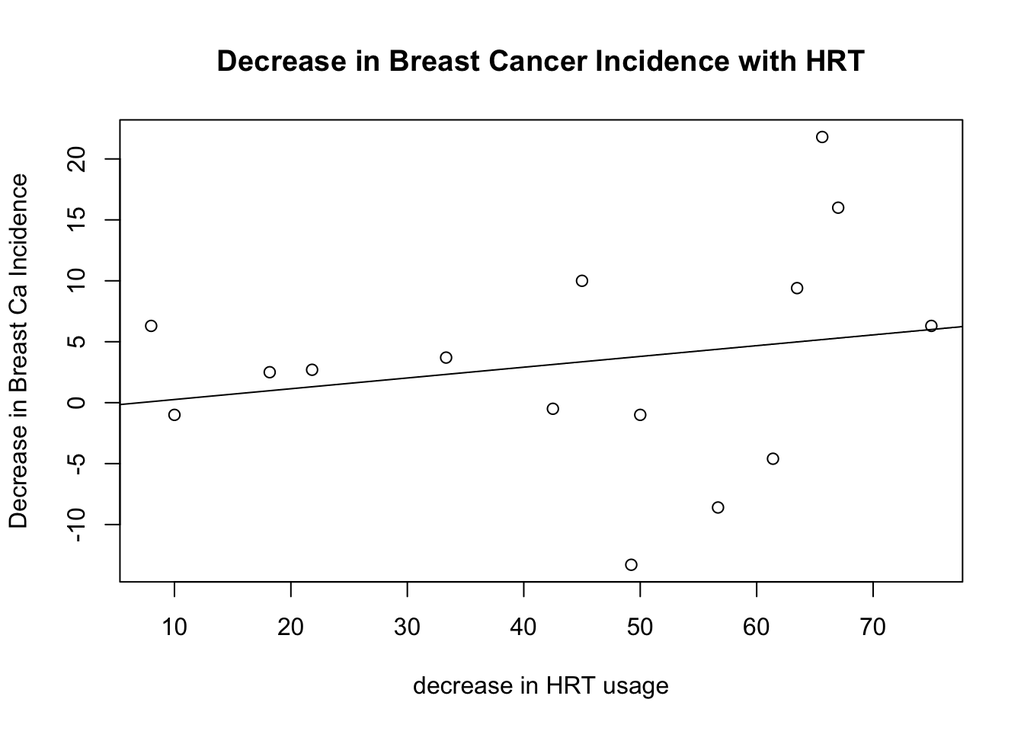

```r
 plot(mydata$declinehrtuse, mydata$cadecrease,
     main = "Decrease in Breast Cancer Incidence with HRT",
    ylab = "Decrease in Breast Ca Incidence",
    xlab = "decrease in HRT usage")

abline(cahrt <- lm(mydata$cadecrease ~ mydata$declinehrtuse,
                  data = mydata))
```

```r
summary(cahrt)
```

```
##
## Call:
## lm(formula = mydata$cadecrease ~ mydata$declinehrtuse, data = mydata)
##
## Residuals:
##     Min      1Q  Median      3Q     Max
## -17.034  -4.220   1.374   5.311  16.614
##
## Coefficients:
##                      Estimate Std. Error t value Pr(>|t|)
## (Intercept)          -0.62479    5.53244  -0.113    0.912
## mydata$declinehrtuse  0.08853    0.11251   0.787    0.445
##
## Residual standard error: 9.132 on 13 degrees of freedom
##   (6 observations deleted due to missingness)
## Multiple R-squared:  0.04546,    Adjusted R-squared:  -0.02796
## F-statistic: 0.6192 on 1 and 13 DF,  p-value: 0.4455
```

Next, we remove data where the decrease in breast cancer were < 0, that is where we noted that breast cancer incidence increased even while the rates of usage of HRT declined.

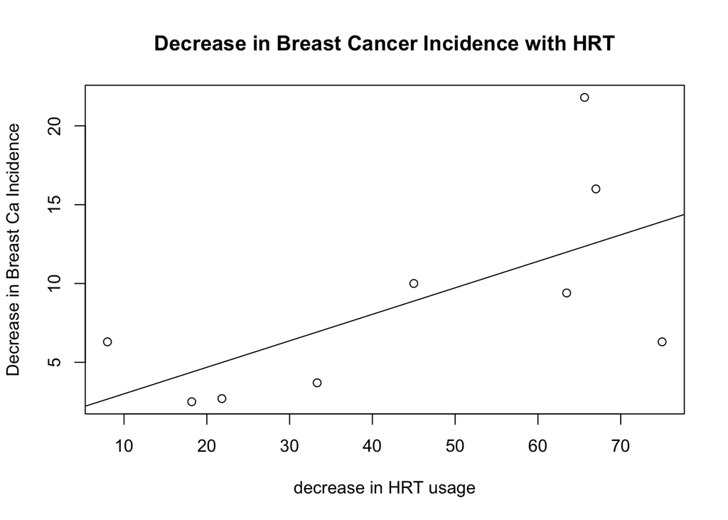

```
##
## Call:
## lm(formula = mydata2$cadecrease ~ mydata2$declinehrtuse, data = mydata2)
##
## Residuals:
##    Min     1Q Median     3Q    Max
## -7.628 -2.590 -1.878  3.416  9.447
##
## Coefficients:
##                       Estimate Std. Error t value Pr(>|t|)
## (Intercept)             1.3222     3.8064   0.347   0.7385
## mydata2$declinehrtuse   0.1681     0.0762   2.206   0.0632 .
## ---
## Signif. codes:  0 '***' 0.001 '**' 0.01 '*' 0.05 '.' 0.1 ' ' 1
##
## Residual standard error: 5.337 on 7 degrees of freedom
## Multiple R-squared:   0.41,  Adjusted R-squared:  0.3258
## F-statistic: 4.865 on 1 and 7 DF,  p-value: 0.06319
```

```
##    Min. 1st Qu.  Median    Mean 3rd Qu.    Max.
##   2.500   3.700   6.300   8.744  10.000  21.800
```

Selecting only those countries that showed decline in breast cancer incidence and HRT usage as well shows a sharper decline rate (beta = 0.17, p = 0.06). This was further tested by examining by creating a binary variable on the basis of the median of the rate of decline (median percentage for the rate of decline in breast cancer incidence was 6.3%, and this was used to classify the countries with decline as high and low ). Alternatively, using the tertiles (33 rd percentiles, the countries with different decline rates were classified)

```
##   highredca declinehrtuse
## 1     FALSE        31.266
## 2      TRUE        60.275
```

As can be seen, for countries that registered more than 6% decline in the breast cancer incidence, the decline in HRT usage was 60.2 percent, nearly twice that of the countries with relatively smaller rate of decline in breast cancer incidence.

```
##
##  (0,3.7] (3.7,10]  (10,21]
##        3        4        1
```

```
##  (0,3.7] (3.7,10]  (10,21]
## 24.44333 47.86750 67.00000
```

As can be seen, the decline in HRT usage was around 67% for the country with over 10% decline in breast cancer decline, while for countries where the decline in breast cancer was less than 4%, there was a decline in HRT usage of around 24%; together, these findings suggest that with progressive decline in HRT usage, there were corresponding decline in breast cancer incidence as well. This was examined in the plot below.

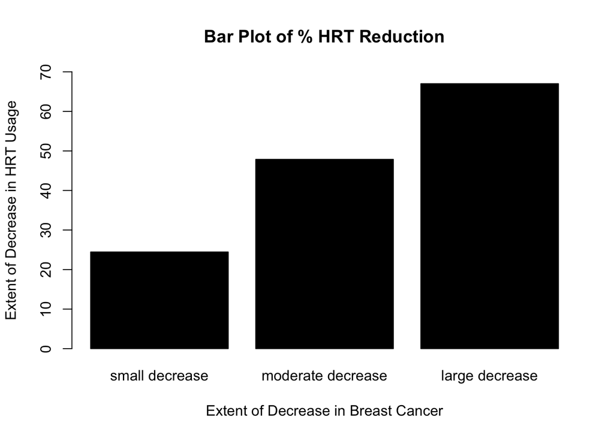

```r
barplot(hrtcadeclevel,
        col = "black", main = "Bar Plot of % HRT Reduction",
        xlab = "Extent of Decrease in Breast Cancer",
        ylab = "Extent of Decrease in HRT Usage",
       names.arg = caredcatnames,
        ylim = c(0, 70))
```